# Can LLMs recover opinions we did not observe?

Session 8 · Prediction, population estimates, and validation

Generative AI in Sociology

2026-10-28

## Suppose we need state opinion but do not have a state survey

Observed

A national survey contains people from every state, but too few respondents in many states for a reliable state estimate.

Wanted

Support for same-sex marriage in each state—and an account of whether state policy responds to those preferences.

What information can legitimately fill the gap between the national sample and the state quantity?

## Several different things can be “missing”

| Target | Example | What we would compare with |
| --- | --- | --- |
| One person’s answer | A respondent skipped `POLVIEWS`. | The held-out answer from that person. |
| A survey item in an earlier year | The GSS did not ask an item in 1988. | A comparable poll from 1988, if one exists. |
| An aggregate quantity | Support for same-sex marriage in Utah. | A sufficiently large state poll or election result. |
| A relationship | Whether policy is more likely where support is higher. | Observed policy and validated opinion estimates. |

A model can perform well on one row and badly on another.

## Lax and Phillips estimate opinion before testing policy responsiveness

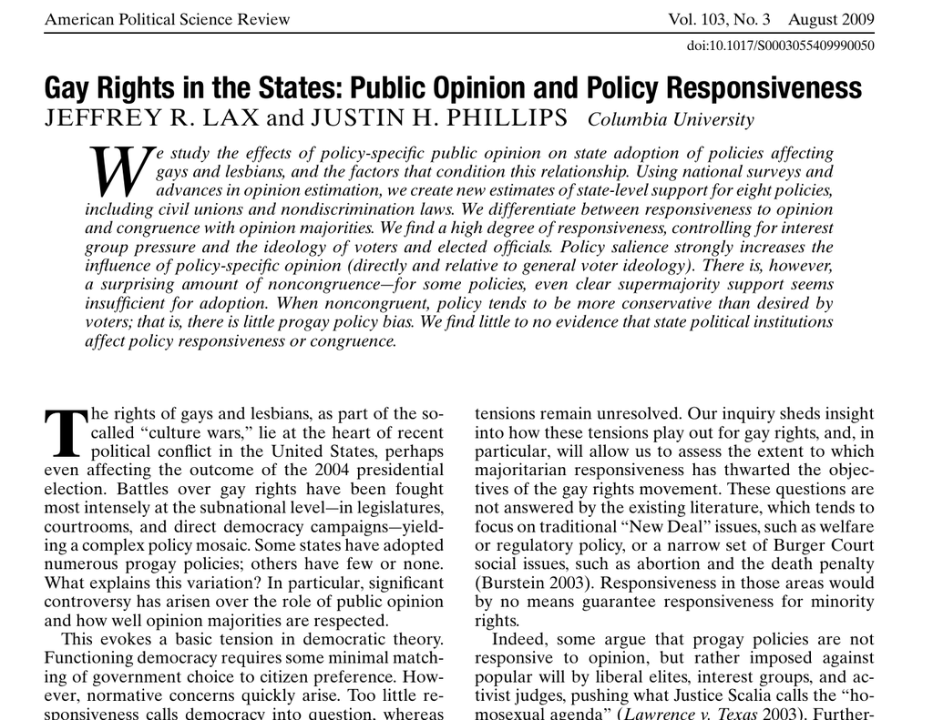

The substantive question is whether state policies on gay and lesbian rights respond to state public opinion.

The obstacle is measurement: national surveys contain too few respondents in many states.

Their approach uses human survey answers, a multilevel model, and population counts—not simulated respondents.

Lax, J. R., and J. H. Phillips. (2009). “Gay Rights in the States: Public Opinion and Policy Responsiveness.” *American Political Science Review* 103(3):367–386. https://doi.org/10.1017/S0003055409990050.

## Multilevel regression and poststratification has two main steps

**1. Estimate responses**

Use observed survey answers to estimate how opinion varies across demographic and geographic groups.

**2. Reweight to the state**

Combine those estimates with known population counts for each demographic cell in each state.

`survey answers`*+*`statistical model`*+*`state population counts`*→*`estimated state opinion`

Lax and Phillips (2009), pp. 371–373 and online appendix.

## The estimated opinion is used inside a substantive analysis

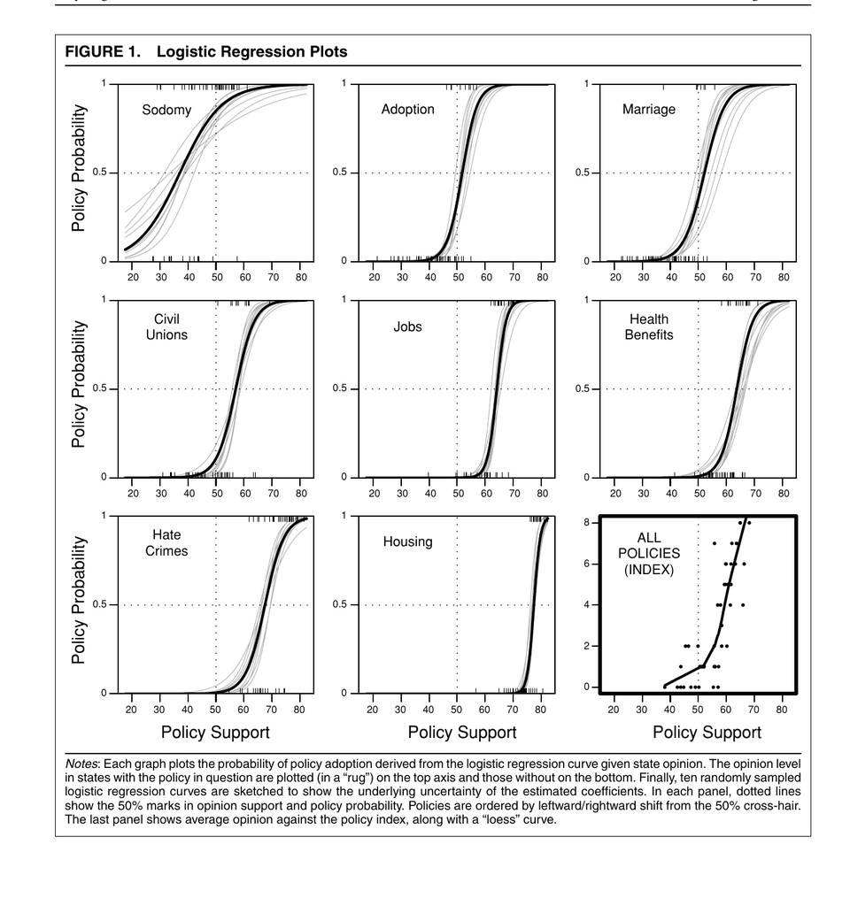

Each panel relates estimated public support to the probability that a state has adopted a policy.

The curves differ across sodomy laws, adoption, marriage, civil unions, jobs, health benefits, hate-crime laws and housing.

The opinion estimate is not the endpoint. It becomes an explanatory variable in a study of democratic responsiveness.

Lax and Phillips (2009), Figure 1, p. 374.

## Their evidence chain remains visible

**Human responses**

People answered real survey questions.

**Population counts**

Census cells tell us who lives in each state.

**Validated estimates**

MRP is compared with direct estimates and election data.

**Policy outcomes**

State law supplies the substantive outcome.

Week 8 asks what changes when an LLM supplies some of the unobserved answers.

## Kim and Lee train a model on survey responses

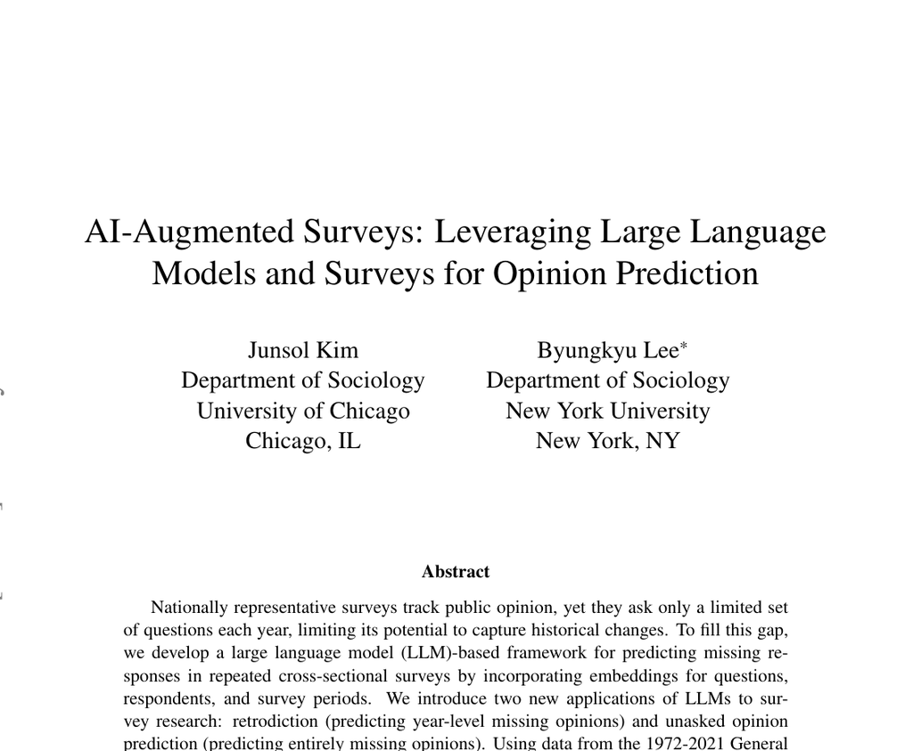

The data are 3,110 binarized opinions from 68,846 GSS respondents between 1972 and 2021.

The model learns from survey questions, respondents’ other answers, and survey years.

The paper asks whether this combination can predict opinions that were not observed.

Kim, J., and B. Lee. (2026). “AI-Augmented Surveys: Leveraging Large Language Models and Surveys for Opinion Prediction.” arXiv:2305.09620v4.

## The paper separates three prediction problems

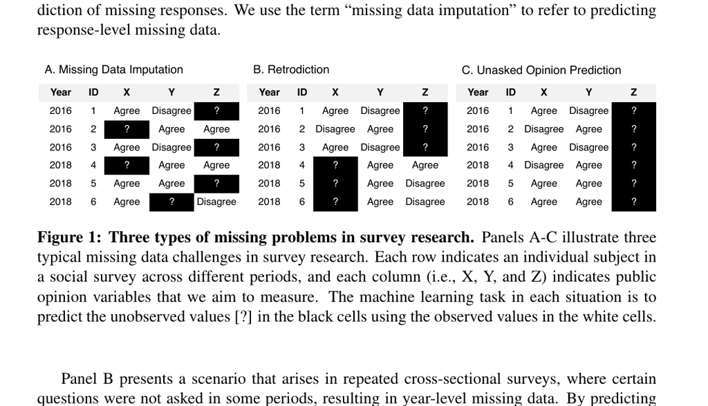

**Imputation**

An answer is missing inside an otherwise observed survey.

**Retrodiction**

An item was not asked in a particular survey year.

**Unasked opinion**

An item has never been asked in the survey data.

Kim and Lee (2026), Figure 1, p. 3.

## This is not an off-the-shelf persona prompt

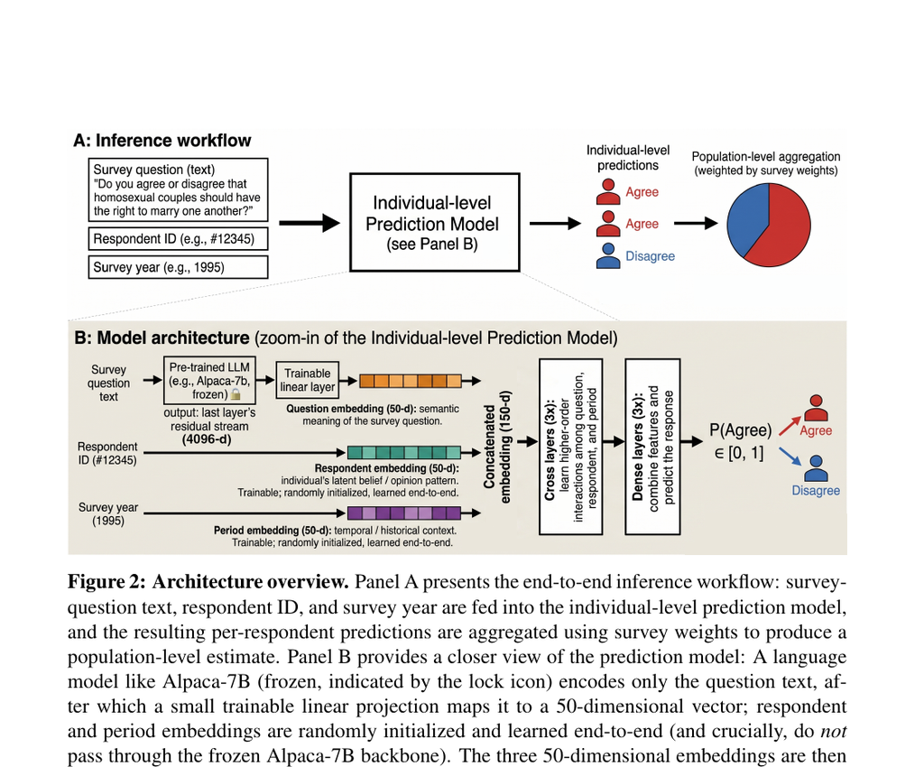

The model incorporates embeddings for the survey question, the respondent and the survey period.

It is fine-tuned on observed GSS responses, then predicts an individual answer that can be aggregated with survey weights.

The human survey data calibrate the model. They are not replaced by a demographic description.

Kim and Lee (2026), Figure 2, p. 7.

## Performance falls as the prediction task becomes harder

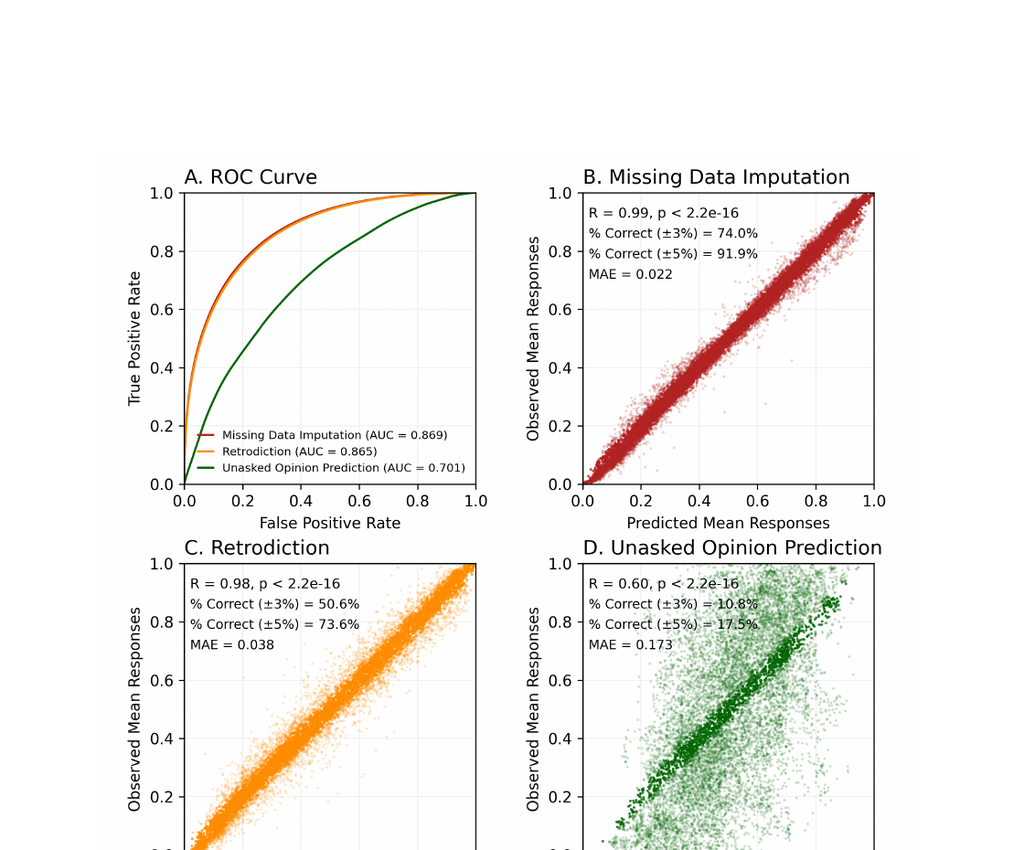

**Imputation:** the model sees closely related observed answers for the same survey setting.

**Retrodiction:** it predicts an item in a year where that item was absent.

**Unasked opinion:** it predicts an item absent from all training waves.

The final task has visibly weaker individual- and aggregate-level performance.

Kim and Lee (2026), Figure 3 and discussion, pp. 15–18.

## Xie and colleagues ask whether synthetic data preserve social structure

[figure not shown]

They evaluate 15 models against four longitudinal and three cross-sectional social-science datasets.

The benchmark does not ask whether individual records sound plausible.

It asks whether the generated population preserves statistical patterns found in the observed data.

Xie, Y., L. Liang, S. Li, et al. (2026). “Evaluating the Statistical Realism of LLM-Generated Social Science Data.” *PNAS* 123(19):e2538145123. https://doi.org/10.1073/pnas.2538145123.

## Their benchmark tests five kinds of population pattern

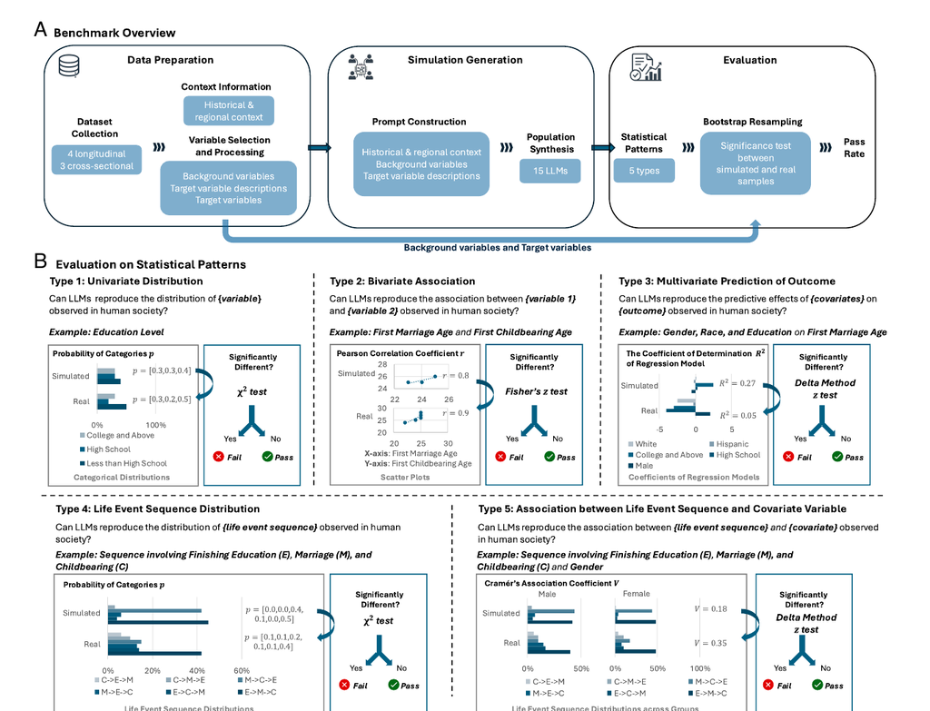

Distributions, bivariate associations, multivariate predictions, life-event sequences, and relationships between sequences and covariates are tested separately.

Xie et al. (2026), Figure 1, p. 3.

## No model passes every type of test reliably

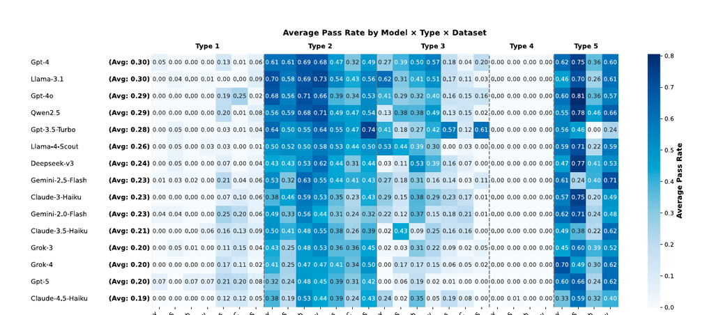

**How to read this:** darker cells indicate a larger share of statistical tests on which simulated and observed data were not significantly different. Performance varies by model, dataset and type of pattern; no row is uniformly dark.

Xie et al. (2026), Figure 2, p. 5.

## The generated data often compress real heterogeneity

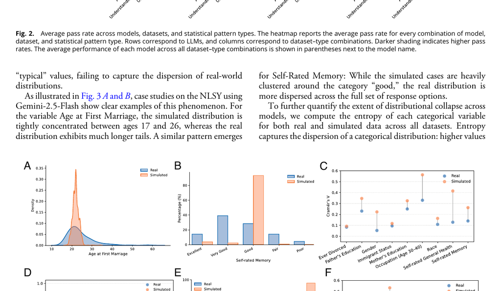

In the observed data, age at first marriage and self-rated memory are dispersed.

Model-generated cases concentrate around more typical values.

The models also tend to produce associations and regression fit that are stronger than those in the human data.

Xie et al. (2026), Figure 3 and discussion, pp. 5–7.

## The three assigned readings answer different questions

| Reading | What is unobserved? | What supplies the estimate? | What is tested? |
| --- | --- | --- | --- |
| Lax & Phillips | State opinion | Human survey responses + MRP + census counts | Opinion estimates and policy responsiveness |
| Kim & Lee | Individual answers or item-year responses | A model trained on GSS responses and embeddings | Held-out individual and aggregate answers |
| Xie et al. | A synthetic population | Prompted LLMs conditioned on sparse profiles | Five kinds of population-level pattern |

## A good result must name the target

**Individual**

Did the model predict this person’s held-out answer?

**Aggregate**

Did the predicted distribution resemble the human distribution?

**Group difference**

Were differences between groups preserved?

**Association**

Were relationships among variables similar?

“The model matches the survey” is not a complete finding.

## After the break: repeat one prediction across five cases

We will make the same structured request through OpenRouter and Ollama, keep every raw return, and compare individual and aggregate results.

## The classroom task is deliberately small

Question

Can either route predict the held-out `POLVIEWS` category for five deidentified GSS profiles?

Input

Five profile dictionaries and the exact seven-category GSS question.

Output

One predicted category and seven probabilities for each profile and route.

Check

Individual exact matches and the aggregate distribution are calculated separately.

## Python stores the five cases as a list of dictionaries

```python
profiles = [
    {"case_id": "p01", "age": 28, "education": "BA",
     "party_id": "Independent", "held_out": 4},
    {"case_id": "p02", "age": 61, "education": "HS",
     "party_id": "Republican", "held_out": 6},
    # three more supplied records
]
```

**`profiles`**

A **list**: an ordered collection containing five items.

**`profiles[0]`**

A **dictionary**: named fields describing one case.

**`profiles[0][“age”]`**

An **integer**: the value `28`.

## The held-out answer is removed from the prompt

```python
profile_for_model = {
    "case_id": profile["case_id"],
    "age": profile["age"],
    "education": profile["education"],
    "party_id": profile["party_id"],
}
```

**Research record**

Contains the profile and the human answer.

*→*

**Model input**

Contains only fields available before prediction.

If `held_out` enters the prompt, this is no longer a prediction exercise.

## The first loop gives us one case at a time

```python
predictions = []

for profile in profiles:
    print("Current case:", profile["case_id"])
```

**Before the loop**

`predictions` is an empty list.

**First iteration**

`profile` refers to the dictionary for `p01`.

**Second iteration**

`profile` refers to `p02`.

`for` repeats the indented lines once for every item in the list.

## Each iteration constructs the complete model message

```python
prompt = f"""
Predict this person's answer to the GSS POLVIEWS question.
Profile: {profile_for_model}
Question: {polviews_question}
Return one category from 1 to 7 and seven probabilities.
"""

messages = [{"role": "user", "content": prompt}]
```

**Input**

One profile dictionary and one question string.

**Operation**

The f-string inserts their current values into the instruction.

**Output**

`messages`, a list containing one message dictionary.

## The OpenRouter branch sends the message to a hosted model

```python
if route == "openrouter":
    with OpenRouter(api_key=api_key) as client:
        response = client.chat.send(
            model=HOSTED_MODEL,
            messages=messages,
            response_format=response_format,
            stream=False,
        )
    raw_json = response.choices[0].message.content
```

**Input:** model name, message list and output schema. **Output:** a response object; `raw_json` retrieves its first answer as text.

## The Ollama branch sends the same research request locally

```python
else:
    response = ollama.chat(
        model=LOCAL_MODEL,
        messages=messages,
        format=prediction_schema,
        options={"temperature": 0},
        think=False,
    )
    raw_json = response.message.content
```

The message has the same purpose, but the transport and response objects differ. Ollama runs the configured model on this computer.

## We preserve the raw return before extracting fields

```python
parsed = json.loads(raw_json)

predictions.append({
    "case_id": profile["case_id"], "route": route,
    "raw_json": raw_json, "predicted": parsed["category"],
    "probabilities": parsed["probabilities"],
    "held_out": profile["held_out"],
})
```

**`raw_json`**

A string exactly as returned.

**`parsed`**

A dictionary made by `json.loads`.

**`predictions`**

A list that grows by one record.

## One check compares predictions case by case

```python
matches = []
for row in predictions:
    same = row["predicted"] == row["held_out"]
    matches.append(same)

accuracy = sum(matches) / len(matches)
```

**Example output**`[True, False, True, False, False]`

`accuracy` is `0.40`: two of five held-out answers were predicted exactly.

**Five human answers**

**Five model predictions**

## Comparing routes does not identify which one represents people

| Observed difference | What we can say | What we cannot say yet |
| --- | --- | --- |
| OpenRouter has higher exact-match accuracy. | It predicted these five held-out cases more often. | It is valid for the target population. |
| Ollama better matches the aggregate. | Its five predictions produce a closer distribution here. | Its individual records are more realistic. |
| The routes disagree on `p02`. | The prediction is sensitive to model and route. | Either answer reveals the person’s “true” opinion. |

## The completion task uses the same five-case routine

Run

Make five predictions through OpenRouter and five through Ollama.

Change one thing

Change the education field for `p02`, then repeat both calls for that case.

Explain

Trace one iteration line by line, including the input object, message, raw return, parsed record and appended result.

Conclude carefully

Report individual and aggregate results separately and identify one comparison still needed for a population claim.

Submit the narrated screen recording by 5:00 p.m. Eastern on the Tuesday before the next class.

## What to take from today

**Prediction has an object**

Name whether it is a person, an item-year, an aggregate or a relationship.

**Validation follows the claim**

A matching mean cannot validate individuals, groups and associations at once.

**Generated data need observed data**

Without a human or population comparison, plausibility is all we have assessed.